# Functions

### Inbuilt functions in python

## Always remember that whenever u do code in structure or in one line i.e using lambda function it is totally depend on programmer in which way he have to write a code

```python
print("hello All welcome to Data Scientist!!!")
```

```
hello All welcome to Data Scientist!!!
```

```python
a=(1,2,3,4,5)
a
```

```
(1, 2, 3, 4, 5)
```

```python
###some functions are
len(a)
```

```
5
```

```python
a=[1,2,3,4,5]
a
```

```
[1, 2, 3, 4, 5]
```

```python
len(a)
```

```
5
```

```python
sum(a)
```

```
15
```

```python
max(a)
```

```
5
```

```python
min(a)
```

```
1
```

```python
a.append(6)
```

```python
a
```

```
[1, 2, 3, 4, 5, 6]
```

```python
a.append(7)
```

```python
a
```

```
[1, 2, 3, 4, 5, 6, 7]
```

# User Defined Functions(UDF)

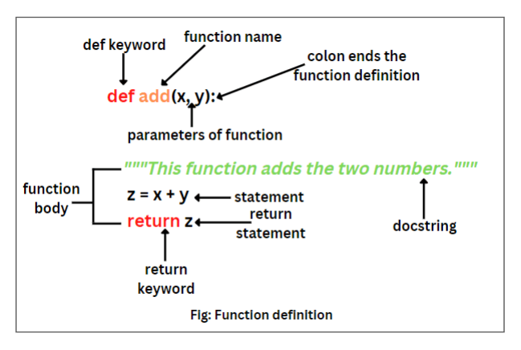

```python
#docstring
#doctring means """----------------------------"""
help(print)
```

```
Help on built-in function print in module builtins:

print(*args, sep=' ', end='\n', file=None, flush=False)
    Prints the values to a stream, or to sys.stdout by default.

    sep
      string inserted between values, default a space.
    end
      string appended after the last value, default a newline.
    file
      a file-like object (stream); defaults to the current sys.stdout.
    flush
      whether to forcibly flush the stream.
```

# 1. Function to output addition of a given numbers

```python
###the purpose to perpare doc string is (it provides information to the user using help(add)
###Always propare a doc string when u repare a function
###You can write comment too
def add(a, b):
    """
    Input : Add two numbers
    Output : Addition of two numbers

    """
    ###Add two numners a and b
    c=a + b
    return c
```

```python
add(6,2)
```

```
8
```

```python
###can store in any variable
a= add(1,9)
```

```python
a
```

```
10
```

```python
b=add(-5,-2)
b
```

```
-7
```

```python
help(add)
```

```
Help on function add in module __main__:

add(a, b)
    Input : Add two numbers
    Output : Addition of two numbers
```

```python
# for doc string --- _____ --- is used for multiple line comment
###for doc string """ _____ """ is used for normal comments
```

# 2. Function to output cube of a given number

```python
def cube(a):
    """
    Input: Enter a number
    Output: Cube root of a number is displayed
    """
    ###Output of a number
    a=a**3
    return a
```

```python
cube(2)
```

```
8
```

```python
cube(5)
```

```
125
```

```python
2*2*2
```

```
8
```

```python
###current file is referred as __ main
help(cube)
```

```
Help on function cube in module __main__:

cube(a)
    Input: Enter a number
    Output: Cube root of a number is displayed
```

```python
###we can store it into a variable
x=cube(4)
x
```

```
64
```

# Give cube of numbers inside a list

```python
def cube_list(a):
    """
    Input: Enter the numbers inside the list
    Output: Cube of numbers is displayed in the list

    """
    ###always write return function outside the loop
    c=[]
    for i in a:
        c.append(i**3)
        print(f'Cube of number {i} is {i**3:.4f}')
    return c
```

```python
b=[1,2,4,5,6]
```

```python
b
```

```
[1, 2, 4, 5, 6]
```

```python
cube_list(b)
```

```
Cube of number 1 is 1.0000
Cube of number 2 is 8.0000
Cube of number 4 is 64.0000
Cube of number 5 is 125.0000
Cube of number 6 is 216.0000
```

```
[1, 8, 64, 125, 216]
```

```python
cube_list(b)
```

```
Cube of number 1 is 1.0000
Cube of number 2 is 8.0000
Cube of number 4 is 64.0000
Cube of number 5 is 125.0000
Cube of number 6 is 216.0000
```

```
[1, 8, 64, 125, 216]
```

```python
c=[1.4,5.3,6.3,2.4]
```

```python
c
```

```
[1.4, 5.3, 6.3, 2.4]
```

```python
p=cube_list(c)
```

```
Cube of number 1.4 is 2.7440
Cube of number 5.3 is 148.8770
Cube of number 6.3 is 250.0470
Cube of number 2.4 is 13.8240
```

```python
p
```

```
[2.7439999999999993,
 148.87699999999998,
 250.04699999999997,
 13.823999999999998]
```

# Calculate sum of elements inside the list

```python
###remember that the function u created should be displayed in blue color
def sum_list(li):
    """
    Input: Enter the numbers inside the list
    Output: Sum of the numbers is displayed in list
    """
    # Initalize sum to 0
    s=0
    # Apply for loop
    for i in li:
        s=s+i
    return s
```

```python
b
```

```
[1, 2, 4, 5, 6]
```

```python
e=sum_list(b)
```

```python
e
```

```
18
```

```python
sum(b)
```

```
18
```

```python
### u can write directly write sum as a function because it itself is a function
def sum(li):
    """
    Input: Enter the numbers inside the list
    Output: Sum of the numbers is displayed in list
    """
    # Initalize sum to 0
    s=0
    # Apply for loop
    for i in li:
        s=s+i
    return s
```

```python
b
```

```
[1, 2, 4, 5, 6]
```

```python
sum(b)
```

```
18
```

# Calculating Product of elements inside the list

```python
def product(l):
    """
    Input: Enter the numbers inside the list
    Output: Sum of the numbers is displayed in list
    """
    # Initalize sum to 0
    s=1
    # Apply for loop
    for i in l:
        s=s*i
    return s
```

```python
b
```

```
[1, 2, 4, 5, 6]
```

```python
product(b)
```

```
240
```

```python
help(product)
```

```
Help on function product in module __main__:

product(l)
    Input: Enter the numbers inside the list
    Output: Sum of the numbers is displayed in list
```

# Write a function to calculate hypotenuse of right angled triangle

```python
###we should use $___$ for raise to value
```

$ c^2= a^2 + b^2 $

Or

$ C= sqrt(a^2 + b^2) $

```python
def hypo(a,b):
    """
    Input: Enter two sides of right angled triangle
    Output: hypotenues of the triagle is displayed

    """
    h=(a**2 + b**2)**(1/2)
    return h
```

```python
hypo(3,4)
```

```
5.0
```

```python
hypo(7,4)
```

```
8.06225774829855
```

```python
c= hypo(12.5,6.2)
```

```python
c
```

```
13.953135848260061
```

# Write a function in python which takes 3 sides and determines whether 3 sides form triangle or not .

Sum of two sides is always greater than sum of third side Sum of two sides > third side

```python
def isTriangle(a,b,c):
    """
    Input:This function takes 3 sides as input
    Output:Tells wheater 3 sides form a triangle or not
    """
    ### here u can use if _ else in boolean value
    if (a+b)>c or (a+c)>b or (b+c)>a:
        t=True
    else:
        t=False
    return t
```

```python
isTriangle(3,4,5)
```

```
True
```

```python
isTriangle(1,2,3)
```

[output not shown]

# Calculate area of triangle when 3 sides are given

### If we have to calculate area of Triangle we have to use Heron's Formula

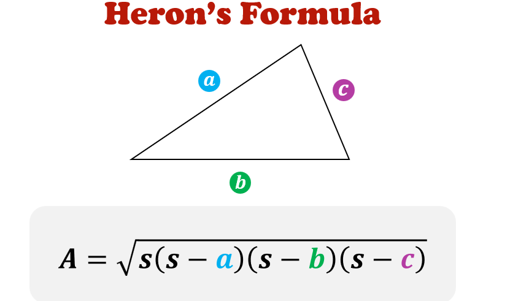

[figure not shown]

### Semi perimeter is the half of perimeter for any shape. That means, by dividing the perimeter of a given figure by 2, we get the semi perimeter.

```python
###here first check it is triangle or not
###always type double equal to while writing any condition
def area(a,b,c):
    """
    This function calculates area of triangle
    when 3 sides are given
    """
    if isTriangle(a,b,c)==True:
        s = (a+b+c)/2
        ar = (s*(s-a)*(s-b)*(s-c))**(1/2)
        ar = round(ar,4)
    else:
        print(f'Sides of {a} , {b} , and {c} DO  NOT FORM A TRIANGLE')
        ar = None
    return ar
```

```python
area(4,5,6)
```

```
9.9216
```

```python
a=area(2.1,5.2,9.1)
a
```

[output not shown]

# Write a function in python to calculate total words used in given sentence

```python
a ="Hii all Welcome to Function Class"
```

```python
a
```

```
'Hii all Welcome to Function Class'
```

```python
a.split()
```

```
['Hii', 'all', 'Welcome', 'to', 'Function', 'Class']
```

```python
len(a.split())
```

```
6
```

```python
a.split()
```

```
['Hii', 'all', 'Welcome', 'to', 'Function', 'Class']
```

```python
### creating a code using above function
```

```python
def split(a):
    """
    Input : Enter the sentence
    Output: Length of the sentence is calculated

    """
    Len = len(a.split())
    return Len
```

```python
split(a)
```

```
6
```

```python
split("Hello Priya")
```

```
2
```

```python
a
```

```
'Hii all Welcome to Function Class'
```

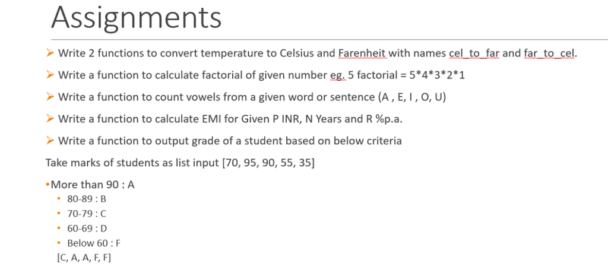

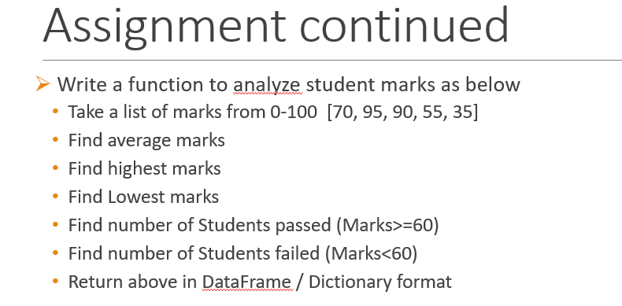

# Functions

## Generator function examples

1. range(start:stop:step)
2. enumerate
3. zip

```python
a=[1,2,3,4]
a
```

```
[1, 2, 3, 4]
```

```python
list(a)
```

```
[1, 2, 3, 4]
```

```python
range(1 , 10 , 2)
```

```
range(1, 10, 2)
```

```python
list(range(1 ,10, 2))
```

```
[1, 3, 5, 7, 9]
```

```python
enumerate(a)
```

```
<enumerate at 0x21544b461b0>
```

```python
list(enumerate(a))
```

```
[(0, 1), (1, 2), (2, 3), (3, 4)]
```

```python
b = 6,7,8,9,10
```

```python
b
```

```
(6, 7, 8, 9, 10)
```

```python
zip(a,b)
```

```
<zip at 0x21544b5df80>
```

```python
list(zip(a,b))
```

```
[(1, 6), (2, 7), (3, 8), (4, 9)]
```

## Whenever genrating sequence of numbers or characters make use of Generator function (Less time)

## Return - Output is given only one time

## Yield - Multiple outputs, usually yield will be inside for loop

## 1. Square for first n natural number : 1, 4, 9, 16, 25, 36, …….

```python
###khali range likha to simple input display hoga
range(1,10)
```

```
range(1, 10)
```

```python
###list(range) likha to list declare hoti hai
list(range(1,10))
```

```
[1, 2, 3, 4, 5, 6, 7, 8, 9]
```

```python
### n , n+1
```

```python
### always remember that yield function should be written inside loop function
def square_seq(n):
    """
     This function generate square of first n natural numbers
    1^2 , 2^2, 3^3, ... , n^2

    """
    for i in range(1, n+1):
        s= i**2
        yield s
```

```python
help(square_seq)
```

```
Help on function square_seq in module __main__:

square_seq(n)
     This function generate square of first n natural numbers
    1^2 , 2^2, 3^3, ... , n^2
```

```python
square_seq(15)
```

```
<generator object square_seq at 0x0000021544B50E50>
```

```python
list(square_seq(15))
```

```
[1, 4, 9, 16, 25, 36, 49, 64, 81, 100, 121, 144, 169, 196, 225]
```

```python
for i in square_seq(15):
    print(i)
```

```
1
4
9
16
25
36
49
64
81
100
121
144
169
196
225
```

```python
###sum of squares of n natural numbers
n= int(input("Enter the number"))

##initialise sum to 0
s=0

###Apply the loop
for i in square_seq(n):
    s=s+i

###Print the sum
print(f'Sum of Square of first {n} natural number is {s}')
```

```
Enter the number9
Sum of Square of first 9 natural number is 285
```

## 2. Write a function in python to generate Fibonacci Series

```python
###always use yield keyword when sequence (series) is asked
def fibo(n):

    """
     This function generates first n fibonacci numbers
      f(n) = f(n-1) + f(n-2)
      0, 1, 1, 2, 3, 5, 8, 13, 21, 34, ....
    """
    a,b= 0,1
    for i in range(n):
        yield a
        a,b = b,a+b
```

```python
fibo(8)
```

```
<generator object fibo at 0x0000021544B50B80>
```

```python
list(fibo(9))
```

```
[0, 1, 1, 2, 3, 5, 8, 13, 21]
```

```python
for i in fibo(15):
    print(i)
```

```
0
1
1
2
3
5
8
13
21
34
55
89
144
233
377
```

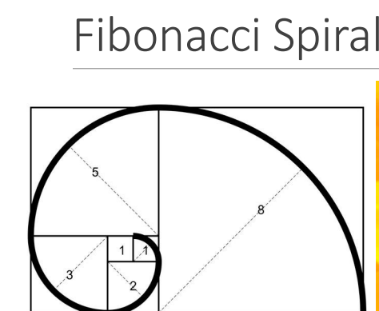

# Anonymous or Lambda Function

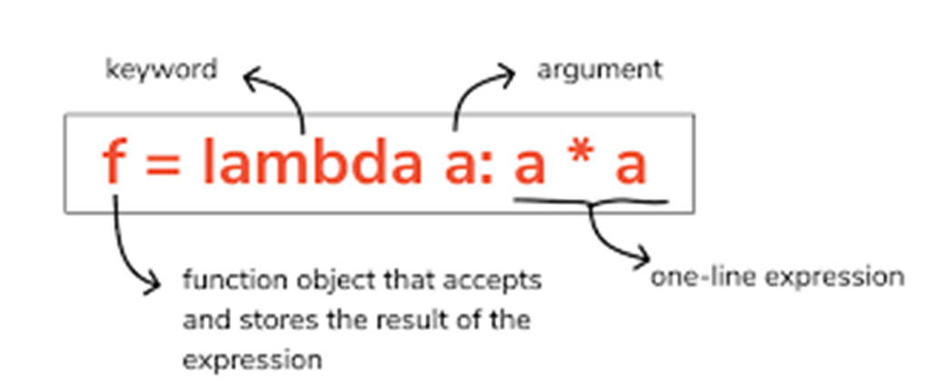

```python
###always write output first after :
sqr=lambda x:x**2
```

```python
sqr(6)
```

```
36
```

```python
a=sqr(5)
a
```

```
25
```

```python
add=lambda a,b: a+b
```

```python
add(8,2)
```

```
10
```

```python
b=add(89,5)
b
```

```
94
```

## Lambda function to calulate hypotenuse

```python
###always write output first after :
hyp = lambda a,b : (a**2 + b**2)**(1/2)
hyp
```

```
<function __main__.<lambda>(a, b)>
```

```python
hyp(9,5)
```

```
10.295630140987
```

```python
###if we want only four digit then usee round function
hyp = lambda a,b : round((a**2 + b**2)**(1/2),4)
hyp
```

```
<function __main__.<lambda>(a, b)>
```

```python
hyp(9,6)
```

```
10.8167
```

## Generate a lambda function which checks whether number is even or odd

```python
###always write output first after :
even_odd = lambda n : "even" if n%2==0 else "odd"
```

```python
even_odd(98)
```

```
'even'
```

```python
even_odd(13)
```

```
'odd'
```

## Generate list with square sequence

```python
###u should always declare list in square brackets if it is in for loop
###list ka sum aaya to for loop mein range likhna hi hai
list_sqr = lambda n : [i**2 for i in range(1,n+1)]
```

```python
list_sqr(15)
```

```
[1, 4, 9, 16, 25, 36, 49, 64, 81, 100, 121, 144, 169, 196, 225]
```

```python
a = list_sqr(6)
a
```

```
[1, 4, 9, 16, 25, 36]
```

## Sum of squares of first n natural numbers

```python
sum_sqr = lambda n : sum[i**2 for i in range(1,n+1)])
```

```
  Cell In[109], line 1
    sum_sqr = lambda n : sum[i**2 for i in range(1,n+1)])
                                                        ^
SyntaxError: unmatched ')'
```

```python
sum_sqr(10)
```

[output not shown]

```python
1**2 + 2**2 + 3**2 + 4**2 + 5**2 + 6**2 + 7**2 + 8**2 + 9**2 + 10**2
```

[output not shown]

## Square of list with map

```python
sqr(14)
```

```
196
```

```python
sqr([1, 2, 3, 11])
```

[output not shown]

```python
###u cant call list directly u have to use map function in mapping of list while passing a list
map(sqr,[1, 2, 3, 11])
```

```
<map at 0x21544af9570>
```

```python
list(map(sqr,[1, 2, 3, 11]))
```

```
[1, 4, 9, 121]
```

```python
map(sqr,range(3,11))
```

```
<map at 0x21544b352d0>
```

```python
list(map(sqr,range(3,11)))
```

```
[9, 16, 25, 36, 49, 64, 81, 100]
```

```python
###suppose apneko 3 - 11 tak chahiye  to range use karna padega
a=list(map(sqr,range(5,14)))
a
```

```
[25, 36, 49, 64, 81, 100, 121, 144, 169]
```

```python
###agar fibonocci series mein kiya map function use then
list(fibo(10))
```

```
[0, 1, 1, 2, 3, 5, 8, 13, 21, 34]
```

```python
list(map(sqr,fibo(14)))
```

```
[0, 1, 1, 4, 9, 25, 64, 169, 441, 1156, 3025, 7921, 20736, 54289]
```

```python
###agar directly list call karni hai aur function mein apply karna hai to
###square root chahiye then
b=[1,2,3,4,5,6]
list(map(lambda x:round( x**(1/2),4),b))
```

```
[1.0, 1.4142, 1.7321, 2.0, 2.2361, 2.4495]
```

```python
###square chahiye then
b=[1,2,3,4,5,6]
list(map(lambda x : x**2,b))
```

```
[1, 4, 9, 16, 25, 36]
```